# Violence Detection System

by [Dolev saadia (Github)](https://github.com/dolevsaadia)and[George koozi (Github)](https://github.com/georgekouzi)

## Introduction

It is a system for detecting violence.

The system uses extracting a set of frames belonging to the video, sending them to a pretrained network called `VGG16`, obtaining the output of one of its final layers and from these outputs train another network called `LSTM`.

LSTM have memory and are able to analyze the temporal information of the video and can distinguish between a video that had violence and a video that did not.

If the dataset `already exists` than`skip the first step` which is to download the data.

## Prerequisites

- [Python3](https://www.python.org/)
- opencv-python
- [numpy](http://www.numpy.org)
- [matplotlib](https://matplotlib.org/users/installing.html)
- [keras](https://pypi.org/project/Keras/)
- [h5py](http://docs.h5py.org/en/stable/build.html)

# How to install

Make sure python3 and pip is installed.

then install:

##### install opencv-python

pip install cv2

pip install numpy

##### install matplotlib

python -m pip install -U matplotlib

##### install keras

pip install Keras

##### install h5py

pip install h5py

# Imports

```python
%matplotlib inline
import cv2
import os
import numpy as np
import keras
import matplotlib.pyplot as plt
import tensorflow.compat.v1 as tf
from random import shuffle
from tensorflow.keras.applications import VGG16
from tensorflow.keras import backend as K
from tensorflow.keras.models import Model, Sequential
from tensorflow.keras.layers import Input
from tensorflow.keras.layers import LSTM
from tensorflow.keras.layers import Dense, Activation
from tensorflow.keras.models import load_model
import sys
import h5py
import sys
import os
import urllib.request
import tarfile
import zipfile
```

```python
tf.__version__
```

```
'2.4.1'
```

# Functions for dataset downloads

#### We will use the function `download_data` to download the datasets

```python
def download_data(in_dir, url):

    if not os.path.exists(in_dir):
        os.makedirs(in_dir)

    maybe_download_and_extract(url,in_dir,'data.zip')
```

#### We will use the function `print_progress` to print the amount of videos processed.

```python
def print_progress(count, max_count):
    # Percentage completion.
    pct_complete = count / max_count

    # Status-message. Note the \r which means the line should
    # overwrite itself.
    msg = "\r- Progress: {0:.1%}".format(pct_complete)

    # Print it.
    sys.stdout.write(msg)
    sys.stdout.flush()
```

#### We will use the function `maybe_download_and_extract` to Download and extract the data if it doesn't already exist.

```python
def maybe_download_and_extract(url, download_dir,filename):

    file_path = os.path.join(download_dir, filename)
    if not os.path.exists(file_path):

        if not os.path.exists(download_dir):
            os.makedirs(download_dir)

        file_path, _ = urllib.request.urlretrieve(url=url,
                                                  filename=file_path,
                                                  reporthook=_print_download_progress)
        print()
        print("Download finished. Extracting files.")

        if file_path.endswith(".zip"):
            zipfile.ZipFile(file=file_path, mode="r").extractall(download_dir)
        elif file_path.endswith((".tar.gz", ".tgz")):
            tarfile.open(name=file_path, mode="r:gz").extractall(download_dir)

        print("Done.")
    else:
        print("Data has apparently already been downloaded and unpacked.")
```

#### We will use the function `_print_download_progress` to print the amount of download processed.

```python
def _print_download_progress(count, block_size, total_size):


    # Percentage completion.
    pct_complete = float(count * block_size) / total_size

    # Status-message. Note the \r which means the line should overwrite itself.
    msg = "\r- Download progress: {0:.1%}".format(pct_complete)

    # Print it.
    sys.stdout.write(msg)
    sys.stdout.flush()
```

#### the url for the dataset`was takken from`https://www.kaggle.com/mohamedmustafa/real-life-violence-situations-dataset

#### we uploaded the dataset to dropbox.

#### define the url.

```python
Dataset_url = "https://uc54a58569d39f5f7d2227578125.dl.dropboxusercontent.com/cd/0/get/BIfiiixbOsPi4C5RqxlbF_I_V8ipHzqjFiUzUPd-uMLYGypZ8kaSFqf7iUVi18bQUxhbFoOZDe-liAMBkEESGUCHPJKwWIsasnNqoJnp8sUax5JZ4E3zMZqYohjMV6NeQ_k/file"
```

# Load Data

#### First of all, we define the directory to place the video dataset

```python
in_dir = "data"
```

```python
download_data(in_dir,Dataset_url)
```

```
Data has apparently already been downloaded and unpacked.
```

```python
data_dir = "data\Real Life Violence Dataset"
```

#### Copy some of the data-dimensions for convenience.

```python
# Frame size
img_size = 224

img_size_touple = (img_size, img_size)

# Number of channels (RGB)
num_channels = 3

# Flat frame size
img_size_flat = img_size * img_size * num_channels

# Number of classes for classification (Violence-No Violence)
num_classes = 2

# Number of files to train
_num_files_train = 1

# Number of frames per video
_images_per_file = 20

# Number of frames per training set
_num_images_train = _num_files_train * _images_per_file

# Video extension
video_exts = ".avi"
```

#### Function used to get 20 frames from a video file and convert the frame to a suitable format for the neural net.

```python
def get_frames(current_dir, file_name):

    in_file = os.path.join(current_dir, file_name)

    images = []

    vidcap = cv2.VideoCapture(file_name)
    success,image = vidcap.read()

    count = 0

    while count<_images_per_file:

        RGB_img = cv2.cvtColor(image, cv2.COLOR_BGR2RGB)

        res = cv2.resize(RGB_img, dsize=(img_size, img_size),
                                 interpolation=cv2.INTER_CUBIC)

        images.append(res)

        success,image = vidcap.read()

        count += 1

    resul = np.array(images)

    resul = (resul / 255.).astype(np.float16)

    return resul
```

#### Function used to label the dataset to Violence and NonViolence

```python
def label_video_names(data_dir):

    # list containing video names
    names = []
    # list containin video labels [1, 0] if it has violence and [0, 1] if not
    labels = []

    dir_name_labales = {
        "data\\Real Life Violence Dataset\\Violence":[1,0],
        "data\\Real Life Violence Dataset\\NonViolence":[0,1]
    }

    for current_dir, dir_names,file_names in os.walk(data_dir):

        for file_name in file_names:

                labels.append(dir_name_labales[current_dir])
                names.append(os.path.join(current_dir, file_name))


    c = list(zip(names,labels))
    # Suffle the data (names and labels)
    shuffle(c)

    names, labels = zip(*c)

    return names, labels
```

## Plot a video frame to see if data is correct

#### get the names and labels of the whole videos

```python
names, labels = label_video_names(data_dir)
```

#### print the path and the name for the chosen video.

```python
names[12]
```

```
'data\\Real Life Violence Dataset\\Violence\\V_707.mp4'
```

#### load 20 frames of one video for example.

```python
frames = get_frames(in_dir, names[12])
```

#### to plot the frames we convert the frames back into uint8 pixel format.

```python
visible_frame = (frames*255).astype('uint8')
```

#### plot frames

[figure not shown]

```python
plt.imshow(visible_frame[3])
```

[figure not shown]

```python
plt.imshow(visible_frame[15])
```

## Pre-Trained Model: VGG16

The following creates an instance of the pre-trained VGG16 model using the Keras API. This automatically downloads the required files, if you don't have them already.

The VGG16 model contains a CNN part and a fully-connected (or dense) part, which is used for classification. If include_top=True then the whole VGG16 model is downloaded, which is about 528 MB. If include_top=False then only the convolutional part of the VGG16 model is downloaded, which is 57 MB.

```python
image_model = VGG16(include_top=True, weights='imagenet')
```

#### Let's see the model summary

```python
image_model.summary()
```

```
Model: "vgg16"
_________________________________________________________________
Layer (type)                 Output Shape              Param #
=================================================================
input_1 (InputLayer)         [(None, 224, 224, 3)]     0
_________________________________________________________________
block1_conv1 (Conv2D)        (None, 224, 224, 64)      1792
_________________________________________________________________
block1_conv2 (Conv2D)        (None, 224, 224, 64)      36928
_________________________________________________________________
block1_pool (MaxPooling2D)   (None, 112, 112, 64)      0
_________________________________________________________________
block2_conv1 (Conv2D)        (None, 112, 112, 128)     73856
_________________________________________________________________
block2_conv2 (Conv2D)        (None, 112, 112, 128)     147584
_________________________________________________________________
block2_pool (MaxPooling2D)   (None, 56, 56, 128)       0
_________________________________________________________________
block3_conv1 (Conv2D)        (None, 56, 56, 256)       295168
_________________________________________________________________
block3_conv2 (Conv2D)        (None, 56, 56, 256)       590080
_________________________________________________________________
block3_conv3 (Conv2D)        (None, 56, 56, 256)       590080
_________________________________________________________________
block3_pool (MaxPooling2D)   (None, 28, 28, 256)       0
_________________________________________________________________
block4_conv1 (Conv2D)        (None, 28, 28, 512)       1180160
_________________________________________________________________
block4_conv2 (Conv2D)        (None, 28, 28, 512)       2359808
_________________________________________________________________
block4_conv3 (Conv2D)        (None, 28, 28, 512)       2359808
_________________________________________________________________
block4_pool (MaxPooling2D)   (None, 14, 14, 512)       0
_________________________________________________________________
block5_conv1 (Conv2D)        (None, 14, 14, 512)       2359808
_________________________________________________________________
block5_conv2 (Conv2D)        (None, 14, 14, 512)       2359808
_________________________________________________________________
block5_conv3 (Conv2D)        (None, 14, 14, 512)       2359808
_________________________________________________________________
block5_pool (MaxPooling2D)   (None, 7, 7, 512)         0
_________________________________________________________________
flatten (Flatten)            (None, 25088)             0
_________________________________________________________________
fc1 (Dense)                  (None, 4096)              102764544
_________________________________________________________________
fc2 (Dense)                  (None, 4096)              16781312
_________________________________________________________________
predictions (Dense)          (None, 1000)              4097000
=================================================================
Total params: 138,357,544
Trainable params: 138,357,544
Non-trainable params: 0
_________________________________________________________________
```

We can observe the shape of the tensors expected as input by the pre-trained VGG16 model. In this case it is images of shape 224 x 224 x 3. Note that we have defined the frame size as 224x224x3. The video frame will be the input of the VGG16 net.

```python
input_shape = image_model.layers[0].output_shape[1:3]
input_shape
```

```
[]
```

The reason for using a cache-file is that it takes a long time to process an image with the VGG16 model. If each image is processed more than once then we can save a lot of time by caching the transfer-values.

When all the videos have been processed through the VGG16 model and the resulting transfer-values are saved in to a cache file, then we can use those transfer-values as the input to LSTM neural network. We will then train the second neural network by using the classes from the violence dataset (Violence, No-Violence), so that the network can learn how to classify images based on the transfer-values from the VGG16 model.

```python
# We will use the output of the layer prior to the final
# classification-layer which is named fc2. This is a fully-connected (or dense) layer.
transfer_layer = image_model.get_layer('fc2')

image_model_transfer = Model(inputs=image_model.input,
                             outputs=transfer_layer.output)

transfer_values_size = K.int_shape(transfer_layer.output)[1]


print("The input of the VGG16 net have dimensions:",K.int_shape(image_model.input)[1:3])

print("The output of the selecter layer of VGG16 net have dimensions: ", transfer_values_size)
```

```
The input of the VGG16 net have dimensions: (224, 224)
The output of the selecter layer of VGG16 net have dimensions:  4096
```

#### Function to process 20 video frames through VGG16 and get transfer values

```python
def get_transfer_values(current_dir, file_name):

    # Pre-allocate input-batch-array for images.
    shape = (_images_per_file,) + img_size_touple + (3,)

    image_batch = np.zeros(shape=shape, dtype=np.float16)

    image_batch = get_frames(current_dir, file_name)

    # Pre-allocate output-array for transfer-values.
    # Note that we use 16-bit floating-points to save memory.
    shape = (_images_per_file, transfer_values_size)
    transfer_values = np.zeros(shape=shape, dtype=np.float16)

    transfer_values = \
            image_model_transfer.predict(image_batch)

    return transfer_values
```

#### Generator that process one video through VGG16 each function call

```python
def proces_transfer(vid_names, in_dir, labels):

    count = 0

    tam = len(vid_names)

    # Pre-allocate input-batch-array for images.
    shape = (_images_per_file,) + img_size_touple + (3,)

    while count<tam:

        video_name = vid_names[count]

        image_batch = np.zeros(shape=shape, dtype=np.float16)

        image_batch = get_frames(in_dir, video_name)

         # Note that we use 16-bit floating-points to save memory.
        shape = (_images_per_file, transfer_values_size)
        transfer_values = np.zeros(shape=shape, dtype=np.float16)

        transfer_values = \
            image_model_transfer.predict(image_batch)

        labels1 = labels[count]

        aux = np.ones([20,2])

        labelss = labels1*aux

        yield transfer_values, labelss

        count+=1
```

#### Functions to save transfer values from VGG16 used for training

```python
def make_files(n_files):

    gen = proces_transfer(names_training, in_dir, labels_training)

    numer = 1

    # Read the first chunk to get the column dtypes
    chunk = next(gen)

    row_count = chunk[0].shape[0]
    row_count2 = chunk[1].shape[0]

    with h5py.File('training.h5', 'w') as f:

        # Initialize a resizable dataset to hold the output
        maxshape = (None,) + chunk[0].shape[1:]
        maxshape2 = (None,) + chunk[1].shape[1:]


        dset = f.create_dataset('data', shape=chunk[0].shape, maxshape=maxshape,
                                chunks=chunk[0].shape, dtype=chunk[0].dtype)

        dset2 = f.create_dataset('labels', shape=chunk[1].shape, maxshape=maxshape2,
                                 chunks=chunk[1].shape, dtype=chunk[1].dtype)

         # Write the first chunk of rows
        dset[:] = chunk[0]
        dset2[:] = chunk[1]

        for chunk in gen:

            if numer == n_files:

                break

            # Resize the dataset to accommodate the next chunk of rows
            dset.resize(row_count + chunk[0].shape[0], axis=0)
            dset2.resize(row_count2 + chunk[1].shape[0], axis=0)

            # Write the next chunk
            dset[row_count:] = chunk[0]
            dset2[row_count:] = chunk[1]

            # Increment the row count
            row_count += chunk[0].shape[0]
            row_count2 += chunk[1].shape[0]

            print_progress(numer, n_files)

            numer += 1
```

#### Functions to save transfer values from VGG16 used for testing

```python
def make_files_test(n_files):

    gen = proces_transfer(names_test, in_dir, labels_test)

    numer = 1

    # Read the first chunk to get the column dtypes
    chunk = next(gen)

    row_count = chunk[0].shape[0]
    row_count2 = chunk[1].shape[0]

    with h5py.File('validation.h5', 'w') as f:

        # Initialize a resizable dataset to hold the output
        maxshape = (None,) + chunk[0].shape[1:]
        maxshape2 = (None,) + chunk[1].shape[1:]


        dset = f.create_dataset('data', shape=chunk[0].shape, maxshape=maxshape,
                                chunks=chunk[0].shape, dtype=chunk[0].dtype)

        dset2 = f.create_dataset('labels', shape=chunk[1].shape, maxshape=maxshape2,
                                 chunks=chunk[1].shape, dtype=chunk[1].dtype)

         # Write the first chunk of rows
        dset[:] = chunk[0]
        dset2[:] = chunk[1]

        for chunk in gen:

            if numer == n_files:

                break

            # Resize the dataset to accommodate the next chunk of rows
            dset.resize(row_count + chunk[0].shape[0], axis=0)
            dset2.resize(row_count2 + chunk[1].shape[0], axis=0)

            # Write the next chunk
            dset[row_count:] = chunk[0]
            dset2[row_count:] = chunk[1]

            # Increment the row count
            row_count += chunk[0].shape[0]
            row_count2 += chunk[1].shape[0]

            print_progress(numer, n_files)

            numer += 1
```

### Split the dataset into training set and test set

We are going to split the dataset into training set and testing. The training set is used to train the model and the test is used to check the model accuracy.

```python
training_set = int(len(names)*0.8)
test_set = int(len(names)*0.2)

names_training = names[0:training_set]
names_test = names[training_set:]

labels_training = labels[0:training_set]
labels_test = labels[training_set:]
```

## make the training set

Then we will process all the video frames for training through VGG16 and save the transfer-values.

```python
make_files(training_set)
```

```
- Progress: 99.9%
```

## make the testing set

Then we will process 20% the video frames for testing through VGG16 and save the transfer-values.

```python
make_files_test(test_set)
```

```
- Progress: 99.8%
```

### Load the cached transfer values into memory

We saved all the video frames transfer-values into a disk, but we have to load those transfer-values into memory in order to train the LSTM net. if you didn't save the transfer-values into disk you would have to process the whole videos each training. It's a time consuming way to processe the videos through VGG16 net.

### functions to load the saved transfer-values into RAM memory.

```python
def process_alldata_training():

    joint_transfer=[]
    frames_num=20
    count = 0

    with h5py.File('training.h5', 'r') as f:

        X_batch = f['data'][:]
        y_batch = f['labels'][:]

    for i in range(int(len(X_batch)/frames_num)):
        inc = count+frames_num
        joint_transfer.append([X_batch[count:inc],y_batch[count]])
        count =inc

    data =[]
    target=[]

    for i in joint_transfer:
        data.append(i[0])
        target.append(np.array(i[1]))

    return data, target
```

```python
def process_alldata_test():

    joint_transfer=[]
    frames_num=20
    count = 0

    with h5py.File('validation.h5', 'r') as f:

        X_batch = f['data'][:]
        y_batch = f['labels'][:]

    for i in range(int(len(X_batch)/frames_num)):
        inc = count+frames_num
        joint_transfer.append([X_batch[count:inc],y_batch[count]])
        count =inc

    data =[]
    target=[]

    for i in joint_transfer:
        data.append(i[0])
        target.append(np.array(i[1]))

    return data, target
```

#### load the saved transfer-values

```python
data, target = process_alldata_training()
```

```python
data_test, target_test = process_alldata_test()
```

## Recurrent Neural Network

A recurrent neuron has an internal state that is being updated every time the unit receives a new input. This internal state serves as a kind of memory. However, it is not a traditional kind of computer memory which stores bits that are either on or off. Instead the recurrent unit stores floating-point values in its memory-state, which are read and written using matrix-operations so the operations are all differentiable. This means the memory-state can store arbitrary floating-point values (although typically limited between -1.0 and 1.0) and the network can be trained like a normal neural network using Gradient Descent.

### Define LSTM architecture

When defining the LSTM architecture we have to take into account the dimensions of the transfer values. From each frame the VGG16 network obtains as output a vector of 4096 transfer values. From each video we are processing 20 frames so we will have 20 x 4096 values per video. The classification must be done taking into account the 20 frames of the video. If any of them detects violence, the video will be classified as violent.

The first input dimension of LSTM neurons is the temporal dimension, in our case it is 20. The second is the size of the features vector (transfer values).

```python
chunk_size = 4096
n_chunks = 20
rnn_size = 512

model = Sequential()
model.add(LSTM(rnn_size, input_shape=(n_chunks, chunk_size)))
model.add(Dense(1024))
model.add(Activation('relu'))
model.add(Dense(50))
model.add(Activation('sigmoid'))
model.add(Dense(2))
model.add(Activation('softmax'))
model.compile(loss='mean_squared_error', optimizer='adam',metrics=['accuracy'])
```

## Model training

```python
def retrain_the_model(ep,modlename):
    epoch = ep
    batchS = 500

    history = modlename.fit(np.array(data[0:750]), np.array(target[0:750]), epochs=epoch,
                    validation_data=(np.array(data[750:]), np.array(target[750:])),
                    batch_size=batchS, verbose=2)
```

```python
epoch = 20
batchS = 500
history = model.fit(np.array(data[0:750]), np.array(target[0:750]), epochs=epoch,
                    validation_data=(np.array(data[750:]), np.array(target[750:])),
                    batch_size=batchS, verbose=2)
```

```
2/2 - 6s - loss: 0.0360 - accuracy: 0.9573 - val_loss: 0.1253 - val_accuracy: 0.8482
2/2 - 6s - loss: 0.0342 - accuracy: 0.9547 - val_loss: 0.1594 - val_accuracy: 0.8024
2/2 - 6s - loss: 0.0401 - accuracy: 0.9467 - val_loss: 0.1215 - val_accuracy: 0.8529
2/2 - 6s - loss: 0.0291 - accuracy: 0.9613 - val_loss: 0.1288 - val_accuracy: 0.8518
2/2 - 7s - loss: 0.0183 - accuracy: 0.9813 - val_loss: 0.1212 - val_accuracy: 0.8529
2/2 - 8s - loss: 0.0167 - accuracy: 0.9853 - val_loss: 0.1560 - val_accuracy: 0.8047
2/2 - 8s - loss: 0.0310 - accuracy: 0.9560 - val_loss: 0.1236 - val_accuracy: 0.8459
2/2 - 8s - loss: 0.0255 - accuracy: 0.9640 - val_loss: 0.1563 - val_accuracy: 0.8082
2/2 - 7s - loss: 0.0302 - accuracy: 0.9587 - val_loss: 0.1225 - val_accuracy: 0.8482
2/2 - 7s - loss: 0.0174 - accuracy: 0.9827 - val_loss: 0.1373 - val_accuracy: 0.8282
2/2 - 7s - loss: 0.0149 - accuracy: 0.9867 - val_loss: 0.1232 - val_accuracy: 0.8529
2/2 - 7s - loss: 0.0176 - accuracy: 0.9813 - val_loss: 0.1507 - val_accuracy: 0.8188
2/2 - 7s - loss: 0.0198 - accuracy: 0.9827 - val_loss: 0.1243 - val_accuracy: 0.8459
2/2 - 7s - loss: 0.0188 - accuracy: 0.9787 - val_loss: 0.1415 - val_accuracy: 0.8235
2/2 - 7s - loss: 0.0165 - accuracy: 0.9813 - val_loss: 0.1245 - val_accuracy: 0.8518
2/2 - 6s - loss: 0.0157 - accuracy: 0.9813 - val_loss: 0.1404 - val_accuracy: 0.8282
2/2 - 6s - loss: 0.0175 - accuracy: 0.9813 - val_loss: 0.1245 - val_accuracy: 0.8529
2/2 - 6s - loss: 0.0167 - accuracy: 0.9813 - val_loss: 0.1323 - val_accuracy: 0.8376
2/2 - 6s - loss: 0.0172 - accuracy: 0.9813 - val_loss: 0.1238 - val_accuracy: 0.8506
2/2 - 7s - loss: 0.0184 - accuracy: 0.9800 - val_loss: 0.1392 - val_accuracy: 0.8329
```

## Test the model

We test the model with 20% of the total videos, that were splited. this videos weren't used to train the model.

```python
result = model.evaluate(np.array(data_test), np.array(target_test))
```

```python
model.save("result.h5")
```

## Print the model accuracy and loss

```python
for name, value in zip(model.metrics_names, result):
    print(name,round(value,2))
```

```
loss 0.14
accuracy 0.83
```

```python
#### funcion for Print the model accuracy as grpah
```

```python
def plot_results(history):
    loss = history.history['loss']
    val_loss = history.history['val_loss']
    acc = history.history['accuracy']
    val_acc = history.history['val_accuracy']

    epochs = range(len(loss))

    plt.figure()
    plt.plot(epochs, loss, 'b', label='Training loss')
    plt.plot(epochs, val_loss, 'r', label='Validation loss')
    plt.legend()
    plt.show()
    plt.plot(epochs, acc, 'b', label='Training accuracy')
    plt.plot(epochs, val_acc, 'r', label='Validation accuracy')
    plt.legend()
    plt.show()
```

## Print the model accuracy and loss

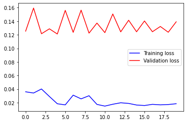

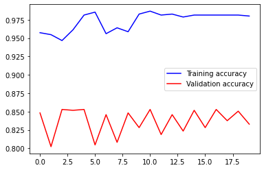

```python
plot_results(history)
```

## Load the model

```python
model = load_model('result.h5')
result = model.evaluate(np.array(data_test), np.array(target_test))
```

## retrain the model

```python
retrain_the_model(20,model)
```

```
2/2 - 6s - loss: 0.0097 - accuracy: 0.9907 - val_loss: 0.1284 - val_accuracy: 0.8482
2/2 - 6s - loss: 0.0101 - accuracy: 0.9907 - val_loss: 0.1374 - val_accuracy: 0.8447
2/2 - 6s - loss: 0.0100 - accuracy: 0.9907 - val_loss: 0.1356 - val_accuracy: 0.8471
2/2 - 6s - loss: 0.0098 - accuracy: 0.9907 - val_loss: 0.1299 - val_accuracy: 0.8482
2/2 - 6s - loss: 0.0099 - accuracy: 0.9907 - val_loss: 0.1329 - val_accuracy: 0.8447
2/2 - 6s - loss: 0.0097 - accuracy: 0.9907 - val_loss: 0.1357 - val_accuracy: 0.8459
2/2 - 6s - loss: 0.0098 - accuracy: 0.9907 - val_loss: 0.1317 - val_accuracy: 0.8459
2/2 - 6s - loss: 0.0097 - accuracy: 0.9907 - val_loss: 0.1312 - val_accuracy: 0.8482
2/2 - 7s - loss: 0.0097 - accuracy: 0.9907 - val_loss: 0.1333 - val_accuracy: 0.8459
2/2 - 7s - loss: 0.0097 - accuracy: 0.9907 - val_loss: 0.1324 - val_accuracy: 0.8494
2/2 - 7s - loss: 0.0096 - accuracy: 0.9907 - val_loss: 0.1316 - val_accuracy: 0.8482
2/2 - 6s - loss: 0.0097 - accuracy: 0.9907 - val_loss: 0.1328 - val_accuracy: 0.8471
2/2 - 6s - loss: 0.0096 - accuracy: 0.9907 - val_loss: 0.1338 - val_accuracy: 0.8471
2/2 - 6s - loss: 0.0096 - accuracy: 0.9907 - val_loss: 0.1318 - val_accuracy: 0.8471
2/2 - 6s - loss: 0.0096 - accuracy: 0.9907 - val_loss: 0.1328 - val_accuracy: 0.8459
2/2 - 6s - loss: 0.0096 - accuracy: 0.9907 - val_loss: 0.1355 - val_accuracy: 0.8482
2/2 - 6s - loss: 0.0097 - accuracy: 0.9907 - val_loss: 0.1321 - val_accuracy: 0.8471
2/2 - 6s - loss: 0.0096 - accuracy: 0.9907 - val_loss: 0.1302 - val_accuracy: 0.8506
2/2 - 7s - loss: 0.0097 - accuracy: 0.9907 - val_loss: 0.1343 - val_accuracy: 0.8459
2/2 - 7s - loss: 0.0096 - accuracy: 0.9907 - val_loss: 0.1349 - val_accuracy: 0.8482
```

```python
model.save("result.h5")
```

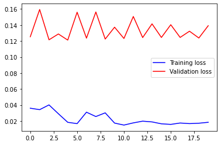

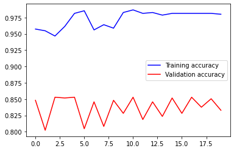

```python
plot_results(history)
```

```python
model = load_model('result.h5')
result = model.evaluate(np.array(data_test), np.array(target_test))
```